# Data Visualization 2: Project

Coffee ratings

Viktória Kónya

16 February, 2022

The report is also available on RPubs.

### Introduction

In this report I am going to analyze the Coffee Ratings dataset which was released on the 28th week of 2020 on [Tidy Tuesday’ GitHub page](https://github.com/rfordatascience/tidytuesday/blob/master/data/2020/2020-07-07/readme.md). The data set contains information about both Arabica and Robusta beans across many countries and professionally rated on a 0-100 scale. Many sorts of scoring are available for each producer such as based on the acidity, sweetness, fragrance and the balance of the coffee which can provide interesting insights o the differences between coffee producing countries. In this analysis I will focus on country level analysis of the coffee ratings and the different dimensions of assessment of the coffee quality as well as its relationship with the growing altitude. With the help of descriptive analytics and data visualization I will try to find answer for the following question: where should I travel if I want to drink the best coffee in the world?

### The dataset

We can import the coffee ratings data set using the **tidytuesdayR** package. The dataset was converted to a data.table object in order to make the subsequent data cleaning and feature engineering more efficient.

```r
# Clear environment
rm(list=ls())

# Import libraries for data management
library(tidytuesdayR)
library(data.table)
library(ggplot2)
library(ggrepel)
library(sf)
library(tidyverse)
library(kableExtra)

# Import dataset
df <- readr::read_csv('https://raw.githubusercontent.com/rfordatascience/tidytuesday/master/data/2020/2020-07-07/coffee_ratings.csv')

# Convert to data table
df <- data.table(df)
```

Let’s take a quick look at the imported dataset.

```r
str(df)
```

```
## Classes 'data.table' and 'data.frame':   1339 obs. of  43 variables:
##  $ total_cup_points     : num  90.6 89.9 89.8 89 88.8 ...
##  $ species              : chr  "Arabica" "Arabica" "Arabica" "Arabica" ...
##  $ owner                : chr  "metad plc" "metad plc" "grounds for health admin" "yidnekachew dabessa" ...
##  $ country_of_origin    : chr  "Ethiopia" "Ethiopia" "Guatemala" "Ethiopia" ...
##  $ farm_name            : chr  "metad plc" "metad plc" "san marcos barrancas \"san cristobal cuch" "yidnekachew dabessa coffee plantation" ...
##  $ lot_number           : chr  NA NA NA NA ...
##  $ mill                 : chr  "metad plc" "metad plc" NA "wolensu" ...
##  $ ico_number           : chr  "2014/2015" "2014/2015" NA NA ...
##  $ company              : chr  "metad agricultural developmet plc" "metad agricultural developmet plc" NA "yidnekachew debessa coffee plantation" ...
##  $ altitude             : chr  "1950-2200" "1950-2200" "1600 - 1800 m" "1800-2200" ...
##  $ region               : chr  "guji-hambela" "guji-hambela" NA "oromia" ...
##  $ producer             : chr  "METAD PLC" "METAD PLC" NA "Yidnekachew Dabessa Coffee Plantation" ...
##  $ number_of_bags       : num  300 300 5 320 300 100 100 300 300 50 ...
##  $ bag_weight           : chr  "60 kg" "60 kg" "1" "60 kg" ...
```

[output cut: 30 more lines]

As the dataset was collected with web scraping there are obviously lots of fields that are out of our interest. Let’s get rid of them first.

```r
# Drop unnecessary fields
drops <- c("lot_number", "ico_number",  "certification_body", "certification_address", "certification_contact",  "altitude", "mill", "farm_name", "company_name",  "bag_weight", "altitude_low_meters", "altitude_high_meters", "in_country_partner", "unit_of_measurement", "owner_1", "number_of_bags", "category_one_defects", "quakers", "expiration", "category_two_defects", "harvest_year", "company", "producer")

df <- df[, (drops) := NULL]

rm(drops)
```

Identifiers and different certificate numbers can be dropped. As the measure of the altitude we are going to use the altitude_mean_meters which is the mean of the higher and lower altitude limits and already converted to meters. We are not going to drill down to producer or farm level so these fields can be also removed. Also the number of coffee bags used for the testing is not relevant for us so we will remove it.

### Technical preparation

In order to unify the outlook of our graps I created a custom theme in advance that we are going to add to each graph.

```r
source("theme_viki.R")
```

Also for the explanatory data analysis custom graph functions were created in advance.

```r
# Histogram
histograms <- function( data, x_var , x_lab, bin ){
  # n = nrow(df)

  ggplot( data , aes(x = x_var)) +
    geom_histogram( aes(y = (..count..)/sum(..count..)), binwidth = bin, fill="#238b45", color = 'gray50', alpha = 0.8, na.rm = T) +
    # stat_function(fun = function(x) dnorm(x, mean = mean(x_var, na.rm = T), sd = sd(x_var, na.rm = T)) * n * bin, color = "darkred", size = 1, na.rm = T) +
    labs(y = 'Percent',x = x_lab ) +
    scale_y_continuous(labels = scales::percent_format(1)) +
    theme_viki()
}

# Boxplot
boxplots <- function( data, x_var , y_var, x_lab , y_lab ){

  ggplot(data, aes(x = factor(x_var), y = y_var)) +
    geom_boxplot( fill="#238b45", alpha = 0.8) +
    stat_boxplot(geom = "errorbar", width = 0.8, size = 0.3, na.rm=T) +
    labs(y = y_lab,x = x_lab ) +
    theme_viki()
}
```

### Data cleaning

Now we can start to explore and clean our dataset. First let’s take a look at the numeric variables.

```r
# Import library
library(modelsummary)

# Summary table
datasummary_skim(df, 'numeric')
```

Unique (#)

Missing (%)

Mean

SD

Min

Median

Max

total_cup_points

180

0

82.1

3.5

0.0

82.5

90.6

aroma

33

0

7.6

0.4

0.0

7.6

8.8

flavor

35

0

7.5

0.4

0.0

7.6

8.8

aftertaste

35

0

7.4

0.4

0.0

7.4

8.7

acidity

31

0

7.5

0.4

0.0

7.6

8.8

body

33

0

7.5

0.4

0.0

7.5

8.6

balance

33

0

7.5

0.4

0.0

7.5

8.8

uniformity

10

0

9.8

0.6

0.0

10.0

10.0

clean_cup

11

0

9.8

0.8

0.0

10.0

10.0

sweetness

17

0

9.9

0.6

0.0

10.0

10.0

cupper_points

42

0

7.5

0.5

0.0

7.5

10.0

moisture

23

0

0.1

0.0

0.0

0.1

0.3

[figure not shown]

altitude_mean_meters

212

17

1775.0

8668.6

1.0

1310.6

190164.0

Our main field of interest is the **total_cup_points** which is the total rating of the coffee and is measured in a 0 to 100 scale. Other 11 individual coffee quality grade measures are also available which are the following: aroma, flavor, aftertaste, acidity, body, balance, uniformity, clean_cup, sweetness, cupper_points, moisture. There are no missings and the range seems fine, so no additional cleaning step is needed for these fields. With the altitude, on the other hand, it seems that there are some data issues. First of all it has extreme values above 190 thousand meters which is higher than the peak of the Mount Everest (8848 meters). Even if we remove these observations from the edge of the distribution, there seems to remain some observations with higher than 6000 meters of growing altitude. If we check some external statistics about coffee producing, it seems that growing altitude above 3000 meters is not likely, hence we I will exclude observations with mean altitude above 3000 meters from the analysis.

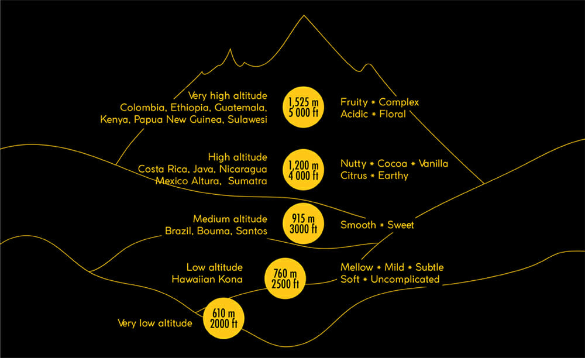

The next step is to take a look at the categorical fields.

```r
# Summary table
datasummary_skim(df, 'categorical')
```

|  |  | N | % |
| --- | --- | --- | --- |
| species | Arabica | 1311 | 97.9 |
|  | Robusta | 28 | 2.1 |
| country_of_origin | Brazil | 132 | 9.9 |
|  | Burundi | 2 | 0.1 |
|  | China | 16 | 1.2 |
|  | Colombia | 183 | 13.7 |
|  | Costa Rica | 51 | 3.8 |
|  | Cote d?Ivoire | 1 | 0.1 |
|  | Ecuador | 3 | 0.2 |
|  | El Salvador | 21 | 1.6 |
|  | Ethiopia | 44 | 3.3 |
|  | Guatemala | 181 | 13.5 |
|  | Haiti | 6 | 0.4 |
|  | Honduras | 53 | 4.0 |
|  | India | 14 | 1.0 |
|  | Indonesia | 20 | 1.5 |
|  | Japan | 1 | 0.1 |
|  | Kenya | 25 | 1.9 |
|  | Laos | 3 | 0.2 |
|  | Malawi | 11 | 0.8 |
|  | Mauritius | 1 | 0.1 |
|  | Mexico | 236 | 17.6 |
|  | Myanmar | 8 | 0.6 |
|  | Nicaragua | 26 | 1.9 |
|  | Panama | 4 | 0.3 |
|  | Papua New Guinea | 1 | 0.1 |
|  | Peru | 10 | 0.7 |
|  | Philippines | 5 | 0.4 |
|  | Rwanda | 1 | 0.1 |
|  | Taiwan | 75 | 5.6 |
|  | Tanzania, United Republic Of | 40 | 3.0 |
|  | Thailand | 32 | 2.4 |
|  | Uganda | 36 | 2.7 |
|  | United States | 10 | 0.7 |
|  | United States (Hawaii) | 73 | 5.5 |
|  | United States (Puerto Rico) | 4 | 0.3 |
|  | Vietnam | 8 | 0.6 |
|  | Zambia | 1 | 0.1 |
|  | NA | 1 | 0.1 |
| variety | Arusha | 6 | 0.4 |
|  | Blue Mountain | 2 | 0.1 |
|  | Bourbon | 226 | 16.9 |
|  | Catimor | 20 | 1.5 |
|  | Catuai | 74 | 5.5 |
|  | Caturra | 256 | 19.1 |
|  | Ethiopian Heirlooms | 1 | 0.1 |
|  | Ethiopian Yirgacheffe | 2 | 0.1 |
|  | Gesha | 12 | 0.9 |
|  | Hawaiian Kona | 44 | 3.3 |
|  | Java | 2 | 0.1 |
|  | Mandheling | 3 | 0.2 |
|  | Marigojipe | 1 | 0.1 |
|  | Moka Peaberry | 1 | 0.1 |
|  | Mundo Novo | 33 | 2.5 |
|  | Other | 110 | 8.2 |
|  | Pacamara | 8 | 0.6 |
|  | Pacas | 13 | 1.0 |
|  | Pache Comun | 1 | 0.1 |
|  | Peaberry | 5 | 0.4 |
|  | Ruiru 11 | 2 | 0.1 |
|  | SL14 | 17 | 1.3 |
|  | SL28 | 15 | 1.1 |
|  | SL34 | 8 | 0.6 |
|  | Sulawesi | 1 | 0.1 |
|  | Sumatra | 3 | 0.2 |
|  | Sumatra Lintong | 1 | 0.1 |
|  | Typica | 211 | 15.8 |
|  | Yellow Bourbon | 35 | 2.6 |
|  | NA | 226 | 16.9 |
| processing_method | Natural / Dry | 258 | 19.3 |
|  | Other | 26 | 1.9 |
|  | Pulped natural / honey | 14 | 1.0 |
|  | Semi-washed / Semi-pulped | 56 | 4.2 |
|  | Washed / Wet | 815 | 60.9 |
|  | NA | 170 | 12.7 |
| color | Blue-Green | 85 | 6.3 |
|  | Bluish-Green | 114 | 8.5 |
|  | Green | 870 | 65.0 |
|  | None | 52 | 3.9 |
|  | NA | 218 | 16.3 |

97.9% of the coffee sample tested was Arabica. Regarding the country of origin, it is important to convert them to standard names that we can later use for the geocoding. I will also introduce a new categorization for the continent. There is one record with missing country which I will remove from the dataset. In case of the variety of the beans, there are a lot of small categories with only a few observations which will be grouped together to a separate ‘Other’ category. Finally, the grading date is in date format. For the later visualizations I will extract the year using the **lubridate** package.

```r
# Import library
library(lubridate)

# Create unique ID
df$ID <- seq_along(df[[1]])

# Correct country names
df[, country_of_origin := ifelse(country_of_origin == 'Cote d?Ivoire', "Ivory Coast", country_of_origin)]
df[, country_of_origin := ifelse(country_of_origin == 'Tanzania, United Republic Of', "Tanzania", country_of_origin)]
df[, country_of_origin := ifelse(country_of_origin == 'United States (Puerto Rico)', "Puerto Rico", country_of_origin)]
df[, country_of_origin := ifelse(country_of_origin == 'United States (Hawaii)', "Hawaii", country_of_origin)]
df[, country_of_origin := ifelse(country_of_origin == 'United States', "USA", country_of_origin)]

# Add continent
africa <- c("Ethiopia","Guatemala","Uganda","Kenya","Tanzania","Burundi","Rwanda","Malawi","Zambia","Mauritius","Ivory Coast")
north_america <- c("USA","Hawaii","Puerto Rico")
south_and_central_america <- c("Costa Rica","Mexico","Brazil","Honduras","Colombia","Panama","El Salvador","Nicaragua","Ecuador","Haiti","Peru")
asia <- c("Indonesia","China","Taiwan","Thailand","Papua New Guinea","Japan","Vietnam","Philippines","Laos","Myanmar","India")

df[, continent_of_origin := fcase(
      country_of_origin %in% africa, 'Africa',
      country_of_origin %in% north_america, 'North America',
      country_of_origin %in% south_and_central_america, 'South and Central America',
      country_of_origin %in% asia, 'Asia')]

# Put small varierty categories (with below 10 observations) to 'Other'
variety_group <- df[!is.na(variety), .(count = .N), by = .(variety)][count < 10]
df[, variety_grouped := ifelse(variety %in% variety_group$variety, 'Other', variety)]

# Drop observations with missing data
df <- df[!is.na(country_of_origin)] # 1 obs.
df <- df[total_cup_points != 0] # 1 obs.

# Extract year from grading date
df[, grading_date_year := year(mdy(grading_date))]

# Exclude observations with 3000+ meters altitude
df <- df[altitude_mean_meters < 3000]

# Metric list
rating_metrics <- c("aroma", "flavor", "aftertaste","acidity", "body", "balance", "uniformity",  "clean_cup", "sweetness", "cupper_points", "moisture")

rm(variety_group, africa, north_america, south_and_central_america, asia)
```

### Explanatory data analysis

Before we start to create analyze the coffee ratings, let’s take a look at the distributions of our variables of interest.

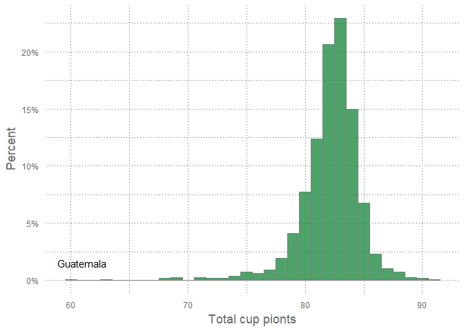

```r
# Histograms
histograms(df, df$total_cup_points, "Total cup pionts", 1) +
  annotate("text", x = 61, y = 0.015, label = "Guatemala")
```

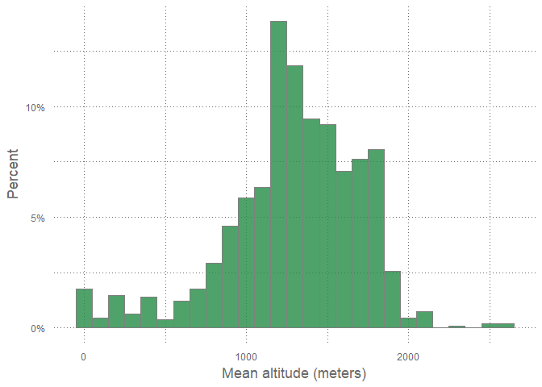

```r
histograms(df, df$altitude_mean_meters, "Mean altitude (meters)", 100)
```

In case of the total coffee ratings, there are 7 observations on the left edge of the distributions which have below 70 score. Regarding the altitude there seems to be some coffee farms where the growing altitude is below 100 meters above the sea level. These vast majority of these farms are located in Brazil so we cannot exclude that there are farms at such low altitude, hence I kept these observations in the dataset.

Let’s also compare the distributions of the different coffee rating metrics. For this, I will use the **ggridges** package which enables us to create nice ridgeline plots.

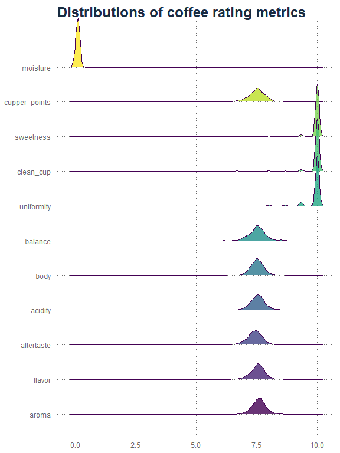

```r
# Import library
library(ggridges)

# Create long dataset
df_long <- melt(df[, .SD, .SDcols =  c("ID", rating_metrics)], id.vars = "ID",
                measure.vars = rating_metrics)

ggplot( df_long, aes(y = variable, x = value, fill = variable, color = "gray10") ) +
  geom_density_ridges(scale = 1.5, alpha = 0.8, show.legend = F) +
  labs(title = 'Distributions of coffee rating metrics') +
  scale_fill_viridis_d() +
  scale_color_viridis_d() +
  theme_viki() +
    theme(
    axis.title.y = element_blank(),
    axis.title.x = element_blank())
```

```r
rm(df_long)
```

The distributions of the coffee quality metrics can be separated into three groups: those centered around 7.5, those with very high ratings around 10 and the moisture of the coffee which has a distribution with the lowest values.

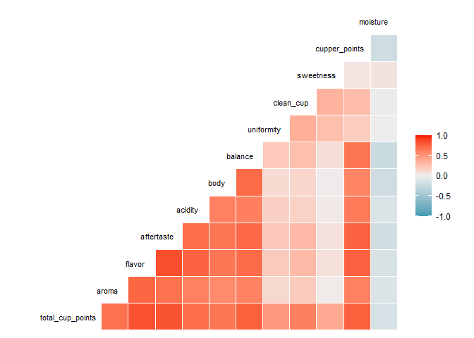

```r
# Import library
library(GGally)

# Correlations
ggcorr(df[, .SD, .SDcols =  c( "total_cup_points", rating_metrics)], hjust = .85, size = 3,layout.exp=2)
```

We can also take a look at the boxplots of the total rating by the categorical fields.

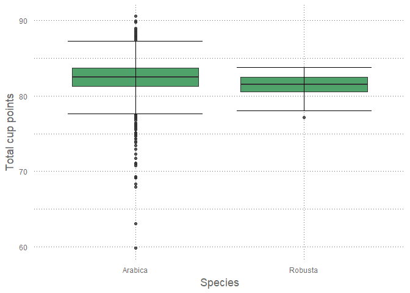

```r
# Boxplots
boxplots(df, df$species, df$total_cup_points, "Species", "Total cup points")
```

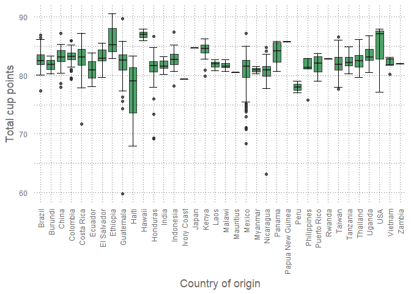

```r
boxplots(df, df$country_of_origin, df$total_cup_points, "Country of origin", "Total cup points") +
  theme(axis.text.x = element_text(angle = 90, vjust = 0.5, hjust=1))
```

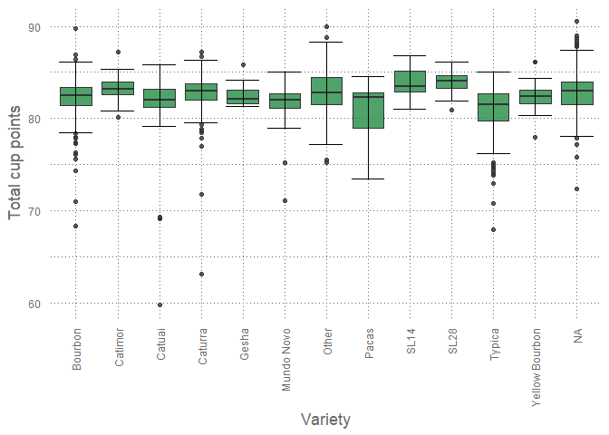

```r
boxplots(df, df$variety_grouped, df$total_cup_points, "Variety", "Total cup points") +
    theme(axis.text.x = element_text(angle = 90, vjust = 0.5, hjust=1))
```

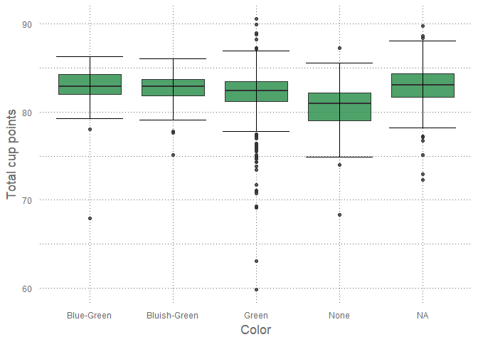

```r
boxplots(df, df$color, df$total_cup_points, "Color", "Total cup points")
```

Now that we are finished with the primary exploration of our coffee dataset we can start to draw further insights from our data.

### Dataviz

#### Country of origination

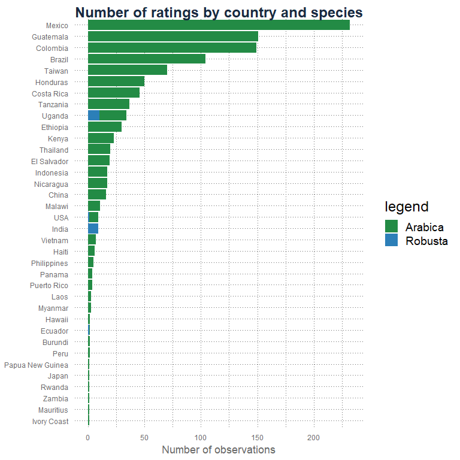

```r
df_country <- df[, .(count = .N) , by = .(country_of_origin, species)][order(-count)]
df_country_rank <- df[, .(count_tot = .N) , by = .(country_of_origin)][order(-count_tot)][, rank := as.numeric(row.names(.SD))]
df_country <- left_join(df_country, df_country_rank, by="country_of_origin")

ggplot( df_country , aes(x = reorder(country_of_origin, -rank), y = count, fill = species) ) +
  geom_bar(stat = "identity" ) +
  labs(title = 'Number of ratings by country and species', y = "Number of observations") +
  scale_fill_manual("legend", values = c( "#238b45", "#2c7fb8")) +
  coord_flip() +
  theme_viki() +
  theme(
    axis.title.y = element_blank())
```

```r
rm(df_country)
```

#### Arabica - Robusta ratio

Let’s check the proportion of ratings of Robusta and Arabica species in the four countries that produce Robusta.

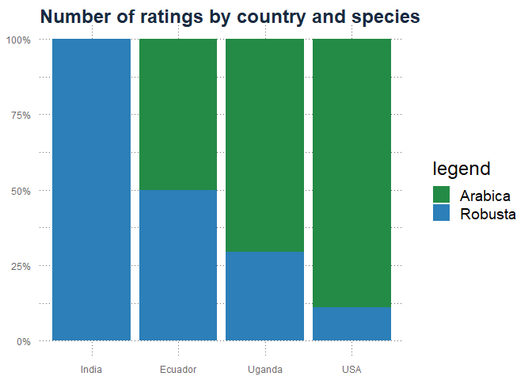

```r
robusta_countries <- df[species == "Robusta", .(count = .N), by =.(country_of_origin)][order(-count)]
df_country <- df[country_of_origin %in% c(robusta_countries$country_of_origin), .(count = .N) , by = .(country_of_origin, species)][, count_robusta := ifelse(species == "Robusta", count, 0)]
robusta_countries <- df_country[, count_country := sum(count), by = country_of_origin][, prop_robusta := count_robusta / count_country][order(country_of_origin)]

ggplot( df_country , aes(x = reorder(country_of_origin, -prop_robusta), y = count, fill = species) ) +
  geom_bar(stat = "identity", position = "fill") +
  labs(title = 'Number of ratings by country and species') +
  scale_fill_manual("legend", values = c( "#238b45", "#2c7fb8")) +
  scale_y_continuous(labels = scales::percent) +
  theme_viki() +
  theme(
    axis.title.y = element_blank(),
    axis.title.x = element_blank())
```

```r
rm(robusta_countries, df_country)
```

India has ratings for only Robusta species, while in the USA their proportion is below 15%.

#### Country ratings

```r
# Create filter for countries with the most rating
df[, count_country_ratings := sum(ifelse(!is.na(total_cup_points), 1, 0) ), by = country_of_origin][, .(country_of_origin, count_country_ratings, total_cup_points)]
```

```
##       country_of_origin count_country_ratings total_cup_points
##    1:          Ethiopia                    30            90.58
##    2:          Ethiopia                    30            89.92
##    3:         Guatemala                   151            89.75
##    4:          Ethiopia                    30            89.00
##    5:          Ethiopia                    30            88.83
##   ---
## 1086:            Uganda                    34            80.50
## 1087:             India                     9            80.17
## 1088:             India                     9            80.17
## 1089:           Ecuador                     2            78.08
## 1090:               USA                     9            77.17
```

[figure not shown]

```r
top_10_count_ratings <- df[, .(count = .N), by = .(country_of_origin, count_country_ratings)][order(-count_country_ratings)][, head(.SD, 15)]


ggplot( df[country_of_origin %in% top_10_count_ratings$country_of_origin] ,
        aes(y = reorder(country_of_origin, total_cup_points), x = total_cup_points, label = owner, fill = stat(x)) ) +
  geom_density_ridges_gradient(scale= 0.9, show.legend = F, alpha = 0.5, point_alpha = 0.5, jittered_points = TRUE) +
  labs(title = 'Top 10 countries based on the number of coffee ratings') +
  scale_fill_viridis_c(alpha = 0.6) +
  theme_viki() +
    theme(
    axis.title.y = element_blank(),
    axis.title.x = element_blank(),
    legend.position="none") +
  geom_label_repel(
    data = subset(df, total_cup_points > 89),
    force = 10,
    xlim = c(85, NA))
```

#### Highest ratings by year

Let’s check that which county achieved the highest coffee rating in each year.

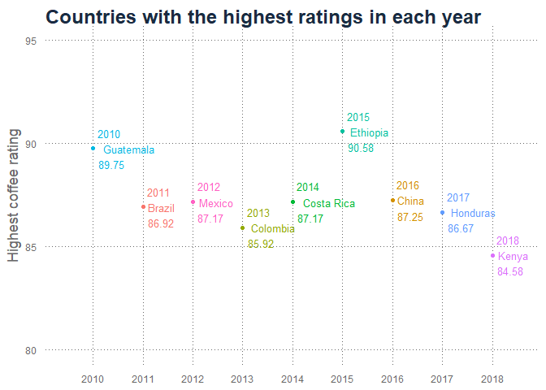

```r
df_yearly_max_rating <- df[!is.na(grading_date_year), .(max_total_cup_points = max(total_cup_points)), by = .(country_of_origin, grading_date_year)][order(grading_date_year, -max_total_cup_points)]
df_yearly_max_rating <- df_yearly_max_rating[, first_by_year := rank( -max_total_cup_points), by = grading_date_year][first_by_year == 1]

ggplot( df_yearly_max_rating , aes(y = max_total_cup_points,
                                   x = grading_date_year,
                                   fill = country_of_origin,
                                   color = country_of_origin,
                                   label=paste0(grading_date_year,"\n",country_of_origin,"\n", max_total_cup_points))) +
  geom_point() +
  geom_text(position = position_dodge(width = 0.9),
            hjust =-0.2,
            size =3.5) +
  ylim(c(80,95)) +
  expand_limits(x= c(2009.5, 2018.5 )) +
  scale_x_continuous(breaks = c(2010:2018)) +
  labs(title = 'Countries with the highest ratings in each year', color = NULL, fill = NULL, label = NULL) +
  ylab("Highest coffee rating") +
  theme_viki() +
  theme(
    axis.title.x = element_blank(),
    legend.position="",
    panel.grid.minor = element_blank()
    )
```

It seems that there is a lot of variation in the leading countries.

#### Coffee growing altitude by countries

We can also investigate the relationship between the coffee ratings and the growing altitude. For this first let’s plot the distribution of the growing altitude by each producing countries.

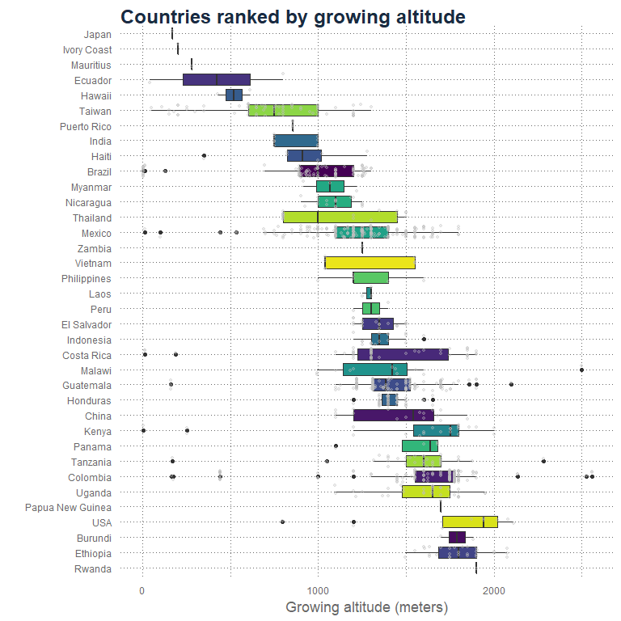

```r
ggplot( df, aes(x=reorder(country_of_origin, -altitude_mean_meters), y=altitude_mean_meters, fill=country_of_origin)) +
  geom_boxplot() +
  geom_jitter(color="grey", alpha=0.3, size=0.9) +
  scale_fill_viridis_d() +
  xlab("") +
  ylab("Growing altitude (meters)") +
  labs(title = 'Countries ranked by growing altitude', color = NULL, fill = NULL, label = NULL) +
  coord_flip() +
  theme_viki() +
  theme(
    legend.position="none")
```

#### Altitude and total cup points

The next scatter plot shows the relationship between the growing altitude and the coffee ratings separately for each continent.

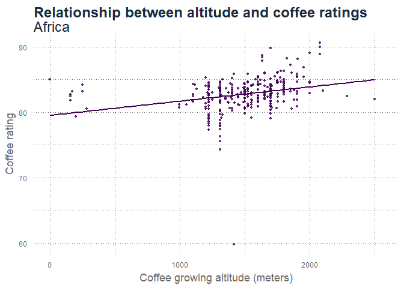

```r
library(gganimate)

ggplot( df , aes(x = altitude_mean_meters,
                 y = total_cup_points,
                 color = continent_of_origin)) +
  geom_point( alpha = 0.8, size = 1) +
  geom_smooth(method = "lm", se = F) +
  transition_states(continent_of_origin, transition_length = 10, state_length = 10) +
  scale_color_viridis_d(begin = 0, end = 0.9)+
  ylab("Coffee rating") +
  xlab("Coffee growing altitude (meters)") +
  labs(title = 'Relationship between altitude and coffee ratings',
    subtitle = '{closest_state}') +
  theme_viki() +
  theme(
    legend.position="none")
```

It seems that farms located at higher altitudes produce higher rated coffee. This positive pattern holds for each continent.

#### Country ranking by different coffee rating measures

As the final score is calculated by the 11 individual rating categories we can expect that some countries perform better in one rating dimension while others achieve higher ratings in another categories. The next animation shows the countries ranked by their mean ratings in each rating category together with their score ranges.

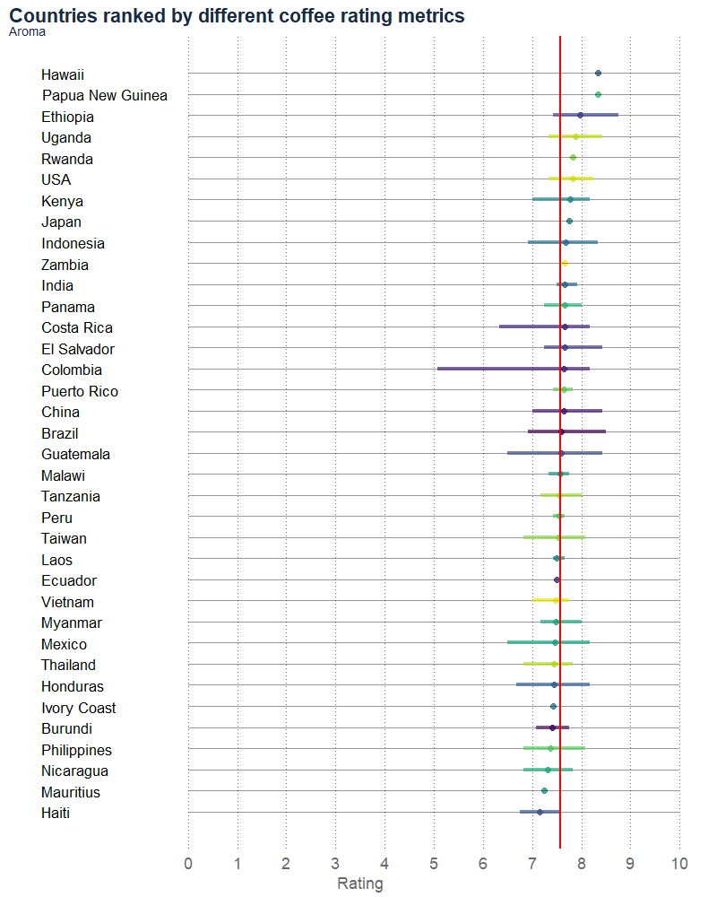

```r
library(stringr)

# Create long dataset
df_long <- melt(df[, .SD, .SDcols =  c("ID", "country_of_origin", rating_metrics)], id.vars = c("ID", "country_of_origin"),
                measure.vars = rating_metrics)

# Create aggregates - Country level
county_aggregates <- df_long[, .(max_value = max(value, na.rm = T),
                                 min_value = min(value, na.rm = T),
                                 mean_value = mean(value, na.rm = T),
                                 rating_number = .N), by = .(country_of_origin, variable)][order(variable, -mean_value, - rating_number, country_of_origin)][, rank := as.numeric(row.names(.SD)), by = variable]

# Create aggregates - Total
total_aggregates <- df_long[, .(max_value_total = max(value, na.rm = T), min_value_total = min(value, na.rm = T), mean_value_total = mean(value, na.rm = T)), by = .(variable)]

# Join datasets
county_aggregates <- left_join(x = county_aggregates, y = total_aggregates, by =c("variable"))


p <- ggplot(county_aggregates, aes(y= -rank)) +
  transition_states(variable, transition_length = 10, state_length = 10) +
  geom_text(aes(x = -3, label = country_of_origin), hjust = -0.01, size = 6) +
  geom_point(aes(x = mean_value, y = -rank, color=country_of_origin), alpha = 0.8 , size = 3) +
  geom_segment(aes(x = 0, y = -rank, xend = 10, yend = -rank),alpha = 0.4, size = 0.5) +
  geom_segment(aes(x = min_value, y = -rank, xend = max_value, yend = -rank, color=country_of_origin),alpha = 0.7, size = 1.5) +
  geom_vline(aes(xintercept = mean_value_total), color = "red", size = 1) +
  scale_x_continuous(breaks = c(0:10)) +
  scale_y_continuous(seq(from = 0, to = 36, by = 1)) +
  scale_color_viridis_d() +
  xlab("Rating")+
  expand_limits(x= c(-3, 10)) +
  labs(
    title = 'Countries ranked by different coffee rating metrics',
    subtitle = '{str_to_title(closest_state)}') +
  theme_viki() +
  theme(
    axis.title.y = element_blank(),
    axis.ticks.y=element_blank(),
    axis.text.y=element_blank(),
    axis.text.x=element_text(size=18),
    axis.title.x = element_text(size=18),
    legend.position="none",
    panel.grid.minor.x = element_blank(),
    panel.grid.minor.y = element_blank(),
    panel.grid.major.y = element_blank(),
    plot.title = element_text(size=22),
    plot.subtitle = element_text(size=14)
    )

animate(p, nframes = 100, fps=5, height = 1000, width =800)
```

```r
anim_save("p.gif")
```

#### Average ratings

The next graph colors the coffee producer countries by their average rating.

```r
library(rworldmap)
library(RColorBrewer)

df_country_species <- df[, .(mean_rating = mean(total_cup_points)), by = .(country_of_origin, species)]
# map_world$filter <- ifelse(map_world$region %in% df_country_species$country_of_origin, map_world$region, NA)

# Create a map-shaped window
mapDevice('x11')

# Join dataset
spdf <- joinCountryData2Map(df_country_species, joinCode="NAME", nameJoinColumn="country_of_origin")
```

```
## 38 codes from your data successfully matched countries in the map
## 1 codes from your data failed to match with a country code in the map
## 208 codes from the map weren't represented in your data
```

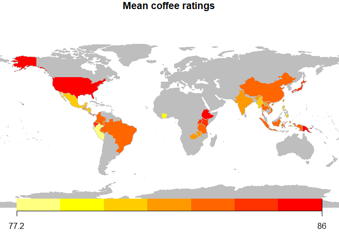

```r
mapCountryData(spdf,
               nameColumnToPlot="mean_rating",
               catMethod="fixedWidth",
               mapTitle = "Mean coffee ratings",
               missingCountryCol = 'grey')
```

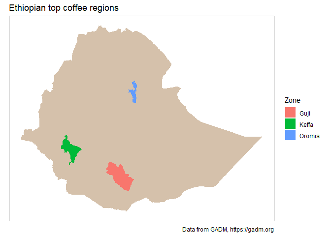

```r
# Filter top regions
df_aggr <- df[country_of_origin == "Ethiopia", .(max_total = max(total_cup_points)), by = .(region)][order(-max_total)]

# Remote file information
u_remote <- "https://biogeo.ucdavis.edu/"
p_remote <- "data/gadm3.6/Rsf/"
f_name <- "gadm36_ETH_3_sf.rds"

# Local file location to save to
ethiopia_rds <- file.path(tempdir(), "gadm36_ETH_3_sf.rds")

if (toupper(Sys.info()["sysname"]) == "WINDOWS") {
  download.file(
    url = paste0(u_remote, p_remote, f_name),
    destfile = ethiopia_rds,
    method = "wininet",
    mode = "wb"
  )
} else {
  download.file(
    url = paste0(u_remote, p_remote, f_name),
    destfile = ethiopia_rds,
    method = "auto"
  )
}

# GADM distributes native R files in .rds format that we then import.
ethiopia_sf <- readRDS(ethiopia_rds)

# Using geom_sf_text() we can add labels to the map.
ethiopia_regions_sf <-
  ethiopia_sf %>%
  mutate(NAME_1 = gsub("SNNP", "Oromia",
                       NAME_1)) %>%
  group_by(NAME_1) %>%
  summarise() %>%
  ungroup() %>%
  st_as_sf()

# First layer, country outline
ethiopia_simple_sf <-
  ethiopia_sf %>%
  group_by(NAME_0) %>%
  summarise() %>%
  ungroup() %>%
  st_as_sf()

# Second layer
ethiopia_zones_sf <-
  ethiopia_sf %>%
  filter(
    NAME_2 %in% c(
      "Guji",
      "Keffa",
      "Oromia"
    )
  )

 # Final map
final_map <- ggplot() +
  geom_sf(data = ethiopia_simple_sf,
          col = NA,
          fill = "#D5C1AB") + # use a coffee-ish colour background for country
  geom_sf(data = ethiopia_zones_sf, # add zones and fill by name
          aes(fill = NAME_2),
          colour = NA)

final_map <-
  final_map +
  labs(
    x = "Longitude",
    y = "Latitude",
    title = "Ethiopian top coffee regions",
    caption = "Data from GADM, https://gadm.org",
    fill = "Zone",
    linetype = "Region"
  ) + theme_bw() +
  theme(panel.grid.major = element_line(colour = "transparent"),
        axis.title.y = element_blank(),
        axis.ticks.y=element_blank(),
        axis.ticks.x=element_blank(),
        axis.text.y=element_blank(),
        axis.text.x=element_blank(),
        axis.title.x = element_blank())

final_map
```